# Методы разграничения доступа.Общий обзор

РОССИЙСКИЙ УНИВЕРСИТЕТ ДРУЖБЫ НАРОДОВ

Кулябов Дмитрий Сергеевич

д.ф.-м.н., профессор

профессор кафедры прикладной информатики и теории вероятностей

Устинова В. В.

Российский университет дружбы народов, Москва, Россия

17 апреля 2026

# Информация

## Докладчик

- Устинова Виктория Вадимовна
- студент НПИбд-01-24
- Российский университет дружбы народов
- 1132243111@pfur.ru
- https://github.com/vikauustin

[figure not shown]

# Оглавление

## Cодержание

1. Вводная часть

2. Цель, гипотеза, задачи и исследования

3. Материалы и методы и инструменты исследования, теоретическая база

4. Содержание исследования

5. Анализ и пректическая значимость достигнутых результатов

6. Общее заключение и выводы

## Вводная часть

*Актуальность*:

- рост кибератак и внутренних угроз
- ужесточение законодательства (152-ФЗ, ФСТЭК)
- удалённая работа → усложнение контроля

*Объект исследования:* информационные системы *Предмет исследования:* методы разграничения доступа

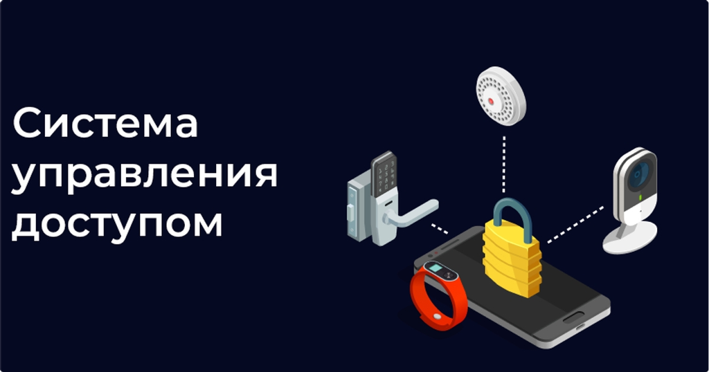

Примеры

## Научиная новизна, практическая значимость работы

*Научная новизна:*

• систематизация методов для современных условий (облака, мобильные устройства, удалёнка)

• рассмотрение гибридных моделей (Windows, SELinux)

*Практическая значимость:*

• готовые рекомендации для администраторов, разработчиков и руководителей

• выбор метода под конкретную задачу

## Цель, гипотеза, задачи и исследования

*Цель:* сравнить методы разграничения доступа и определить их применимость

*Гипотеза:* универсального метода не существует — выбор зависит от требований к безопасности, сложности и среды

*Задачи:*

- Изучить теоретические основы
- Рассмотреть DAC, MAC, RBAC, ABAC, POLP
- Сравнить методы по критериям
- Дать рекомендации

## Материалы и методы и инструменты исследования, теоретическая база

Материалы: научные статьи, документация Windows/Linux, стандарты (Orange Book, ГОСТ Р 56545-2015)

Методы: анализ, синтез, сравнительный анализ, классификация

Теоретическая база:

1. модель HRU (Харрисон – Руццо – Ульман)
2. мандатная модель Белла – Лападулы
3. ролевая модель Сандху (RBAC)
4. атрибутная модель (ABAC)

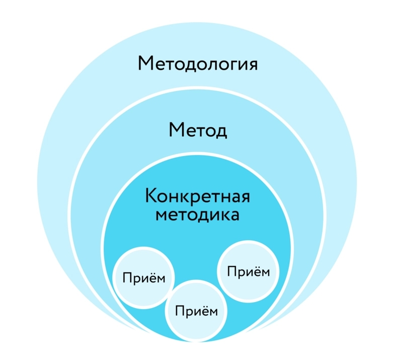

Методы

## Содержание исследования

**Предлагаемое решение задач с обоснованием**

Подход: сравнительно-аналитический

Почему:каждый метод рассматривается отдельно (суть, примеры, плюсы, минусы), затем методы сравниваются по единым критериям

на основе сравнения — рекомендации

Обоснование: только так можно понять, почему один метод подходит для одних условий, а другой — для других

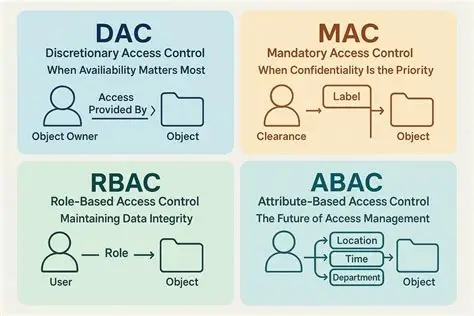

Разные доступы

## Основные этапы(1-3)

Этап 1. Базовые понятия: субъект, объект, права, матрица доступа

Этап 2. DAC (избирательный):

владелец решает, кто получает доступ

примеры: chmod (Linux), разрешения NTFS (Windows)

гибко, но небезопасно

Этап 3. MAC (мандатный):

система задаёт метки (секретно, совершенно секретно)

примеры: SELinux, FreeBSD MAC, военные системы

безопасно, но негибко

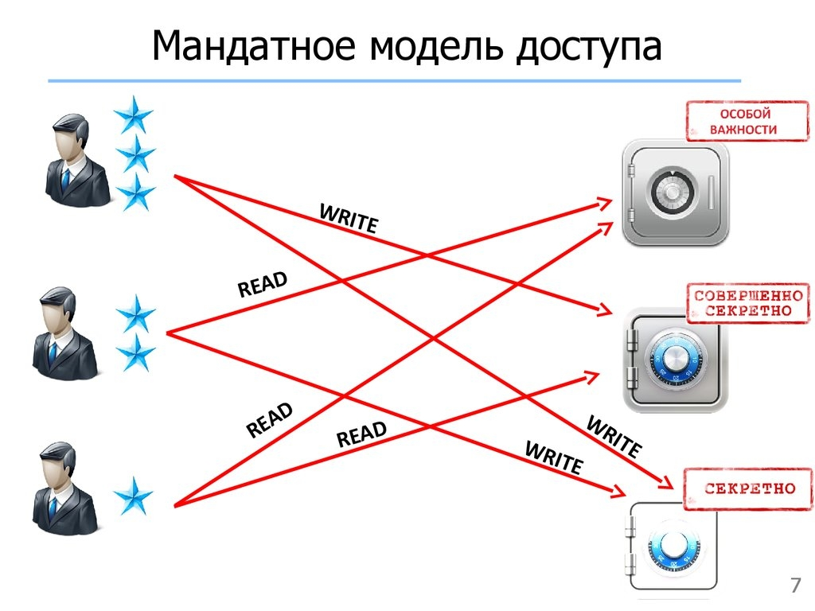

MAC

## Основные этапы(4-6)

Этап 4. RBAC (ролевой):

права через роли (бухгалтер, менеджер, админ)

примеры: Active Directory, 1С, базы данных

Этап 5. ABAC (атрибутный):

доступ по атрибутам (должность, время, место, устройство)

примеры: AWS IAM, Azure AD

Этап 6. POLP (наименьшие привилегии):

давать ровно столько прав, сколько нужно

примеры: UAC (Windows), sudo (Linux)

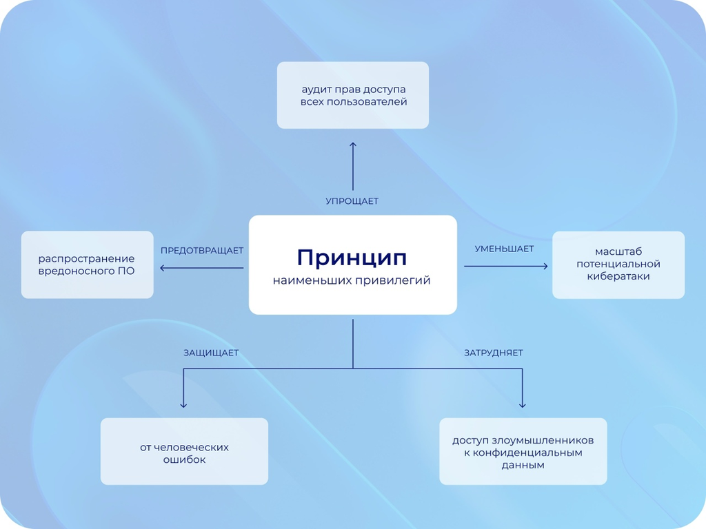

POLP

## Анализ и практическая значимость достигнутых результатов

**Результаты сравнения:** DAC: гибкий, но низкая безопасность, MAC: безопасный, но негибкий, RBAC: золотая середина, ABAC: гибкий + безопасный, но сложный, POLP: обязательное дополнение к любому методу

**Практические рекомендации:**Дом / малый офис → DAC + POLP, Организация с иерархией → RBAC + POLP, Секретные данные → MAC + POLP, Облака / распределённые системы → ABAC + POLP

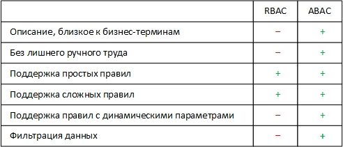

## Общее заключение и выводы

**Выводы:**

1. Универсального метода не существует
2. На практике часто используются гибридные модели (Windows: DAC + RBAC, SELinux: MAC поверх DAC)
3. ABAC + POLP — современный стандарт для облачных и распределённых систем
4. Правильный выбор метода — основа безопасности любой информационной системы

*Итог:* метод выбирается под конкретную задачу с учётом требований к безопасности, сложности и среды